# HW6

Trey Davidson

2024-10-03

### Question 1

A.)

Subset selection will most likely have smallest RSS as it looks at every possible model.

B.)

This can not be guartneed as Subset collection has the possibility of overfitting to training.

i.) True because once a predicter is added in the foward model, then it will never be removed.

ii.) True because one is removed.

iii).False backward and foward selection do not guartnee the samle predictators.

iv.) False again backward and foward selection do not guartnee the same results.

v.) False subset looks at the best model for k predictors meaning that a preidctor could be useful for k, but not for k + 1. Unlike foward and backward, which just adds or removes the best one meaning if you are in k model, then you will be in k + 1 model.

### Question 2

A.) Lasso is less flexaible meaning bias is higher, and variance is lower. Meaning that if the increase in bias is less then the decrease in variance the model will have more predictave accuracy.

Answer is iii

B.)

Just like lasso ridge decrease flexability so we would epect iii for the same reasons

Answer is iii

C.)

Non linnear methods are more flexabile therefore they will increase accuracy when the abs(increase in varinace) is less then the abs(decrease in bias).

```r
library(ISLR2)



set.seed(11)
# This sets the % of test and train
train_fraction <- 0.5

train_indices <- sample(seq_len(nrow(College)), size = floor(train_fraction * nrow(College)))

train_data <- College[train_indices, ]
test_data <- College[-train_indices, ]

model <- lm(Apps ~ ., data = train_data)


predictions <- predict(model, newdata = test_data)

actual_values <- test_data$Apps

mae <- mean(abs(actual_values - predictions))

mse <- mean((actual_values - predictions)^2)

rmse <- sqrt(mse)


# Linnear Regression Test Error
rmse
```

```
## [1] 1012.964
```

```r
# Load necessary libraries
library(ISLR2)
library(glmnet)
```

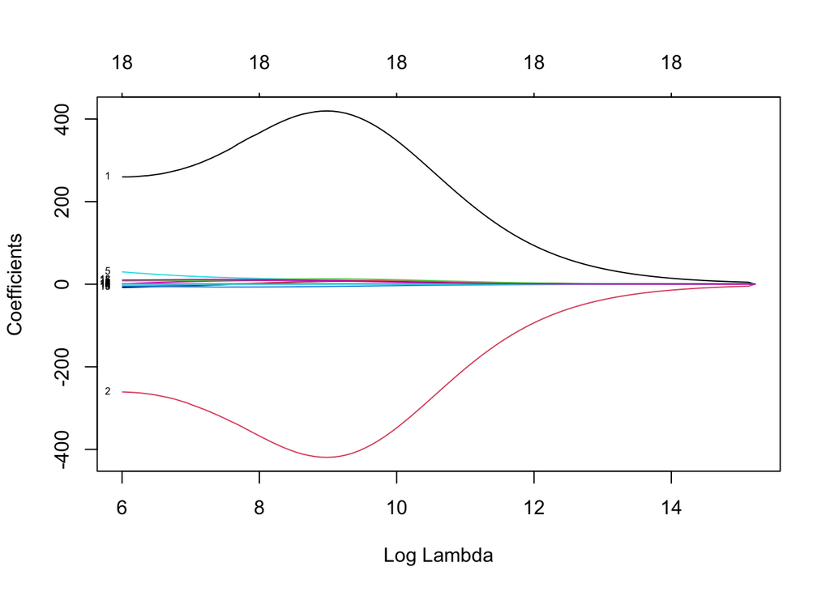

```r
set.seed(11)
train_fraction <- 0.5

train_indices <- sample(seq_len(nrow(College)), size = floor(train_fraction * nrow(College)))

train_data <- College[train_indices, ]
test_data <- College[-train_indices, ]


x=model.matrix(Apps~. -1, data=train_data)
y=train_data$Apps

fit.ridge=glmnet(x, y, alpha=0)
plot(fit.ridge, xvar="lambda", label = TRUE)
```

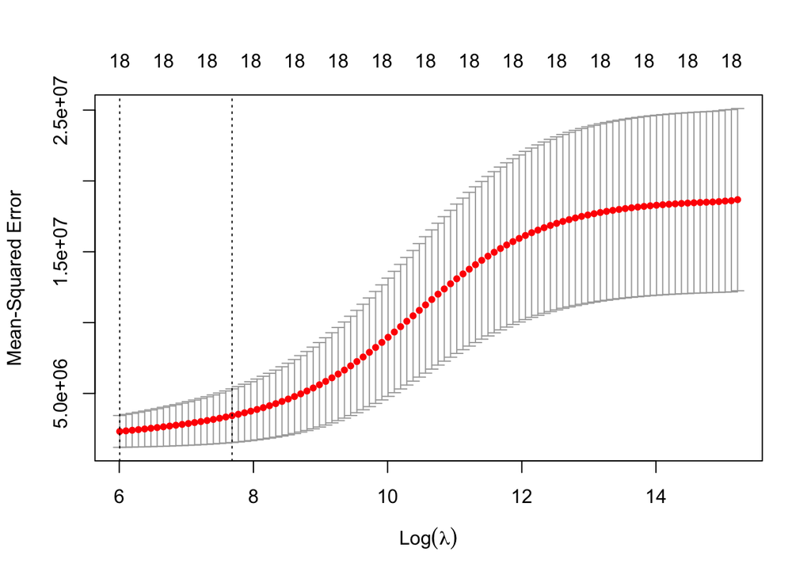

```r
cv.ridge=cv.glmnet(x, y, alpha=0)

#Cross Validation
plot(cv.ridge)
```

```r
best_lambda <- cv.ridge$lambda.min


final_model = glmnet(x, y, alpha = 0, lambda = best_lambda)


x_test = model.matrix(Apps ~ . - 1, data = test_data)


predictions = predict(fit.ridge, s = best_lambda, newx = x_test)


test_error = mean((predictions - test_data$Apps)^2)

#The ridge regression test error is
test_error
```

```
## [1] 967836.6
```

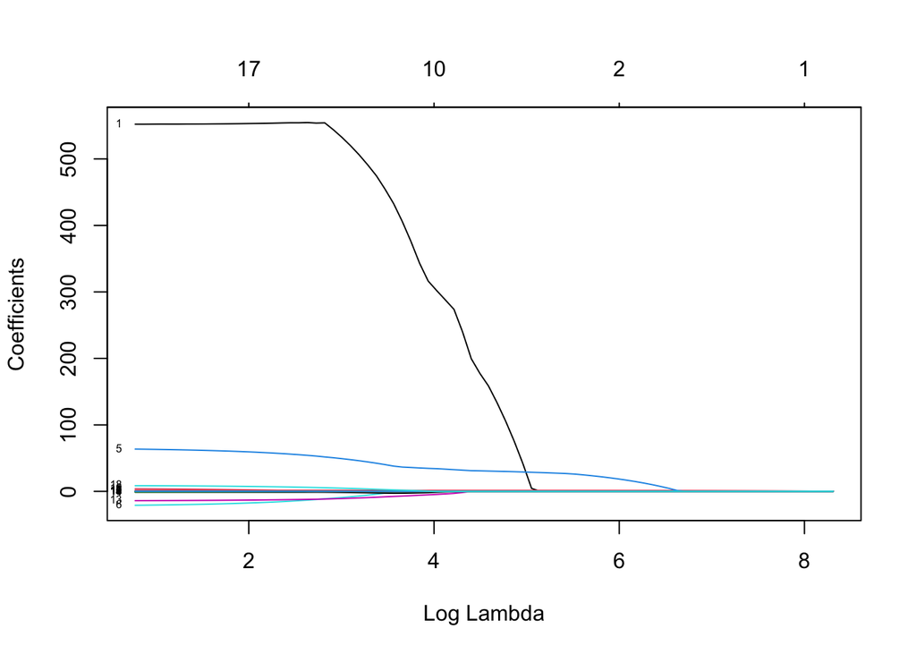

```r
set.seed(11)
train_fraction <- 0.5

train_indices <- sample(seq_len(nrow(College)), size = floor(train_fraction * nrow(College)))

train_data <- College[train_indices, ]
test_data <- College[-train_indices, ]



x=model.matrix(Apps~. -1, data=train_data)
y=train_data$Apps

fit.lasso=glmnet(x, y)
plot(fit.lasso, xvar="lambda", label = TRUE)
```

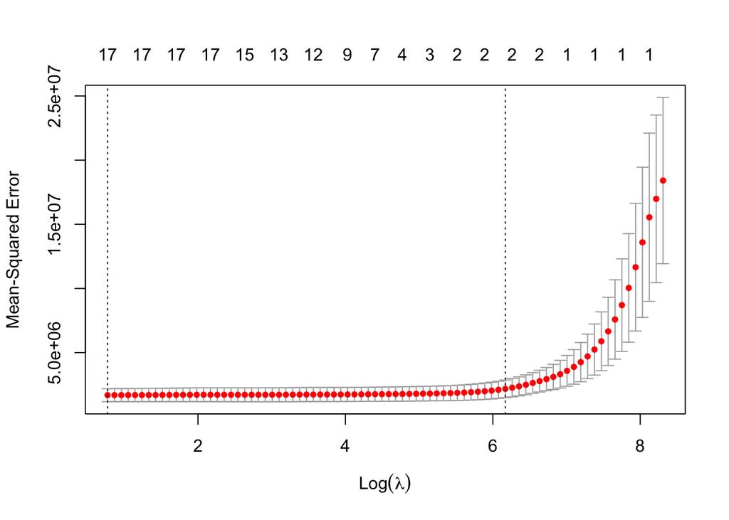

```r
cv.lasso=cv.glmnet(x, y)

#Cross Validation
plot(cv.lasso)
```

```r
lasso_model = glmnet(x, y, alpha = 0, lambda = best_lambda)


x_test = model.matrix(Apps ~ . - 1, data = test_data)


predictions = predict(fit.lasso, s = best_lambda, newx = x_test)


test_error = mean((predictions - test_data$Apps)^2)


print(test_error)
```

```
## [1] 1013264
```

```r
coef(lasso_model)
```

```
## 19 x 1 sparse Matrix of class "dgCMatrix"
##                        s0
## (Intercept) -1.615047e+03
## PrivateNo    2.524842e+02
## PrivateYes  -2.669827e+02
## Accept       1.118425e+00
## Enroll       3.668663e-01
## Top10perc    2.967874e+01
## Top25perc    7.768542e-01
## F.Undergrad  8.908866e-02
## P.Undergrad  4.860045e-03
## Outstate    -3.291341e-02
## Room.Board   2.249533e-01
## Books        5.321231e-02
## Personal     5.304220e-02
## PhD         -7.824848e+00
## Terminal    -4.239532e+00
## S.F.Ratio    7.751853e+00
## perc.alumni -4.548545e+00
## Expend       6.023233e-02
## Grad.Rate    9.962564e+00
```

```r
library(ISLR2)
library(pls)
set.seed(11)


train_fraction <- 0.5
train_indices <- sample(seq_len(nrow(College)), size = floor(train_fraction * nrow(College)))
train_data <- College[train_indices, ]
test_data <- College[-train_indices, ]


pcr_model <- pcr(Apps ~ ., data = train_data, validation = "CV")


summary(pcr_model)
```

```
## Data:    X dimension: 388 17
##  Y dimension: 388 1
## Fit method: svdpc
## Number of components considered: 17
##
## VALIDATION: RMSEP
## Cross-validated using 10 random segments.
##        (Intercept)  1 comps  2 comps  3 comps  4 comps  5 comps  6 comps
## CV            4306     4386     2124     2081     1800     1495     1432
## adjCV         4306     4393     2120     2077     1782     1479     1423
##        7 comps  8 comps  9 comps  10 comps  11 comps  12 comps  13 comps
## CV        1428     1430     1435      1377      1341      1344      1355
## adjCV     1419     1419     1424      1366      1331      1334      1344
##        14 comps  15 comps  16 comps  17 comps
## CV         1303      1276      1278      1274
## adjCV      1293      1266      1267      1264
##
## TRAINING: % variance explained
##       1 comps  2 comps  3 comps  4 comps  5 comps  6 comps  7 comps  8 comps
## X     49.8508    87.71    95.62    97.51    98.74    99.51    99.91    99.97
## Apps   0.1206    77.18    78.22    88.30    91.00    91.04    91.11    91.50
##       9 comps  10 comps  11 comps  12 comps  13 comps  14 comps  15 comps
## X       100.0    100.00    100.00    100.00    100.00     100.0     100.0
## Apps     91.5     92.14     92.51     92.51     92.51      92.9      93.3
##       16 comps  17 comps
## X       100.00    100.00
## Apps     93.32     93.43
```

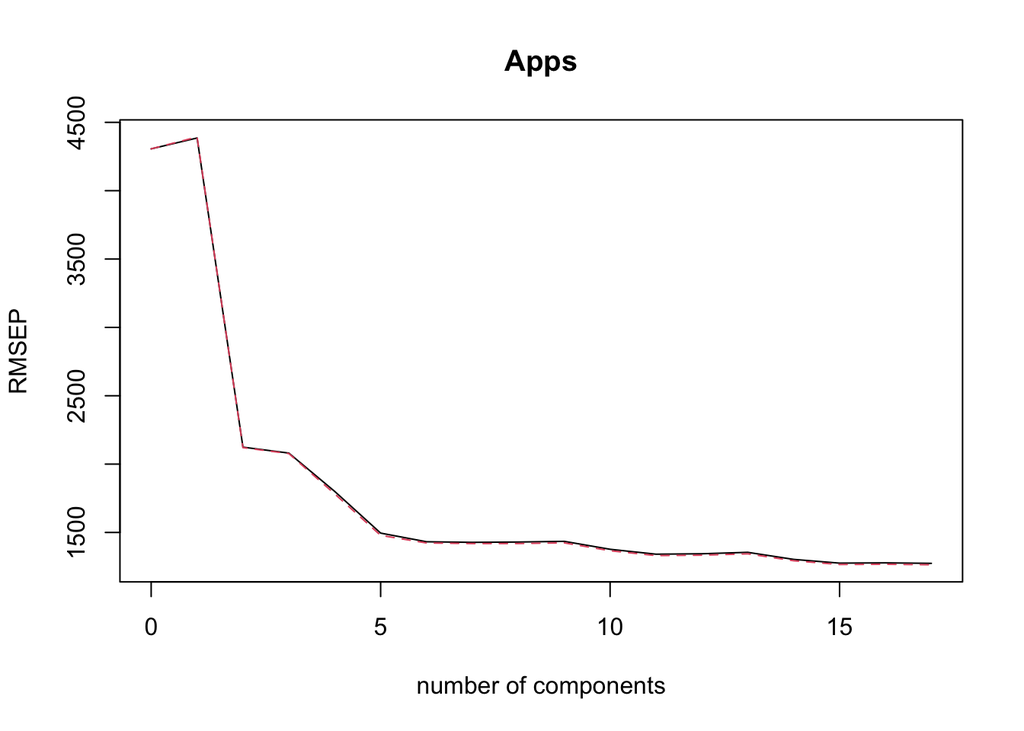

```r
plot(pcr_model, plottype = "validation")
```

```r
optimal_ncomp <- which.min(pcr_model$validation$PRESS)


predictions <- predict(pcr_model, newdata = test_data, ncomp = optimal_ncomp)


test_error <- mean((predictions - test_data$Apps)^2)


print(test_error)
```

```
## [1] 1026096
```

```r
library(ISLR2)
library(pls)


set.seed(11)


train_fraction <- 0.5
train_indices <- sample(seq_len(nrow(College)), size = floor(train_fraction * nrow(College)))
train_data <- College[train_indices, ]
test_data <- College[-train_indices, ]


pls_model <- plsr(Apps ~ ., data = train_data, validation = "CV")


summary(pls_model)
```

```
## Data:    X dimension: 388 17
##  Y dimension: 388 1
## Fit method: kernelpls
## Number of components considered: 17
##
## VALIDATION: RMSEP
## Cross-validated using 10 random segments.
##        (Intercept)  1 comps  2 comps  3 comps  4 comps  5 comps  6 comps
## CV            4306     2092     1944     1778     1472     1432     1442
## adjCV         4306     2081     1882     1767     1460     1423     1432
##        7 comps  8 comps  9 comps  10 comps  11 comps  12 comps  13 comps
## CV        1435     1414     1383      1336      1315      1286      1275
## adjCV     1424     1405     1376      1326      1305      1275      1265
##        14 comps  15 comps  16 comps  17 comps
## CV         1275      1277      1282      1274
## adjCV      1265      1267      1272      1264
##
## TRAINING: % variance explained
##       1 comps  2 comps  3 comps  4 comps  5 comps  6 comps  7 comps  8 comps
## X       37.86    55.47    91.81    97.41    98.71    99.12    99.56    99.97
## Apps    78.72    85.10    87.92    90.91    91.16    91.32    91.46    91.52
##       9 comps  10 comps  11 comps  12 comps  13 comps  14 comps  15 comps
## X       99.98    100.00    100.00     100.0    100.00    100.00    100.00
## Apps    92.12     92.56     92.88      93.3     93.31     93.31     93.32
##       16 comps  17 comps
## X       100.00    100.00
## Apps     93.32     93.43
```

[figure not shown]

```r
plot(pls_model, plottype = "validation")
```

```r
optimal_ncomp <- which.min(pls_model$validation$PRESS)


predictions <- predict(pls_model, newdata = test_data, ncomp = optimal_ncomp)

test_error <- mean((predictions - test_data$Apps)^2)


test_error
```

```
## [1] 1026096
```